# Quarterly Results of my Master’s Thesis

Author

Simon Knapstein

This document presents the results of the quarterly event studies conducted for my Master’s Thesis using different specifications of fixed effects (FE).

During my final presentation, we discussed whether I had employed yearly instead of quarterly fixed effects in order to better isolate the effects of my hypotheses from potential seasonal variations.

Upon reviewing my code, I found that I had used time-unit fixed effects, meaning that each quarter was treated as a separate time period rather than as the same quarter across years. Therefore, I additionally experimented with specifications including (i) quarter fixed effects independent of the year and (ii) both quarter and year fixed effects simultaneously.

**Aggregation error**

All district-level radiance values used in this document were computed using

```
extract(light_masked, gadm_vector,
       fun = sum,
       na.rm = TRUE)
```

This sums all pixel-level radiance values within a district and therefore biases the measure toward districts with a larger area, as they contain more pixels. Apparent differences in brightness—such as higher radiance in Taliban-controlled districts—and the near-normal shape of the histograms show this aggregation method.

# Event Studies

**H1 Poppy cultiavtion**

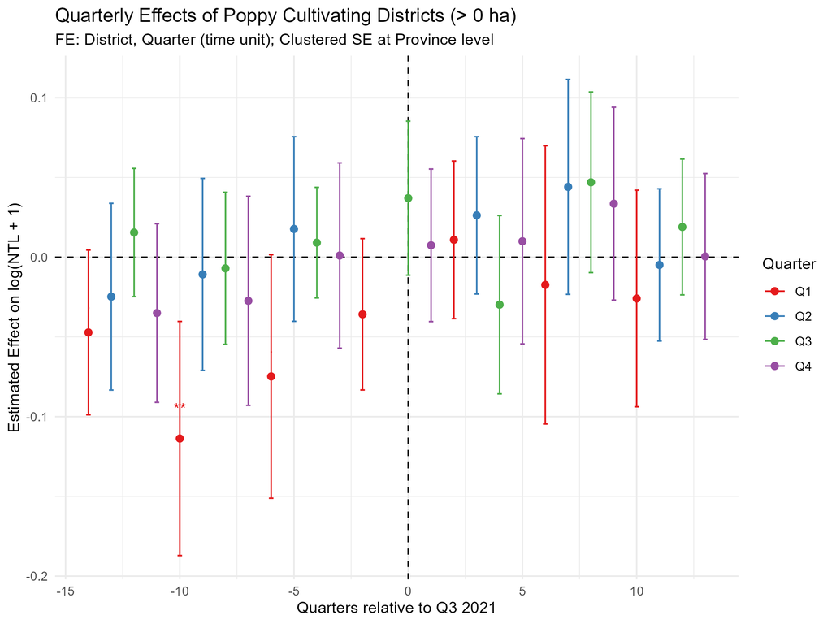

**H1a Poppy Ban**

For 2022 ban:

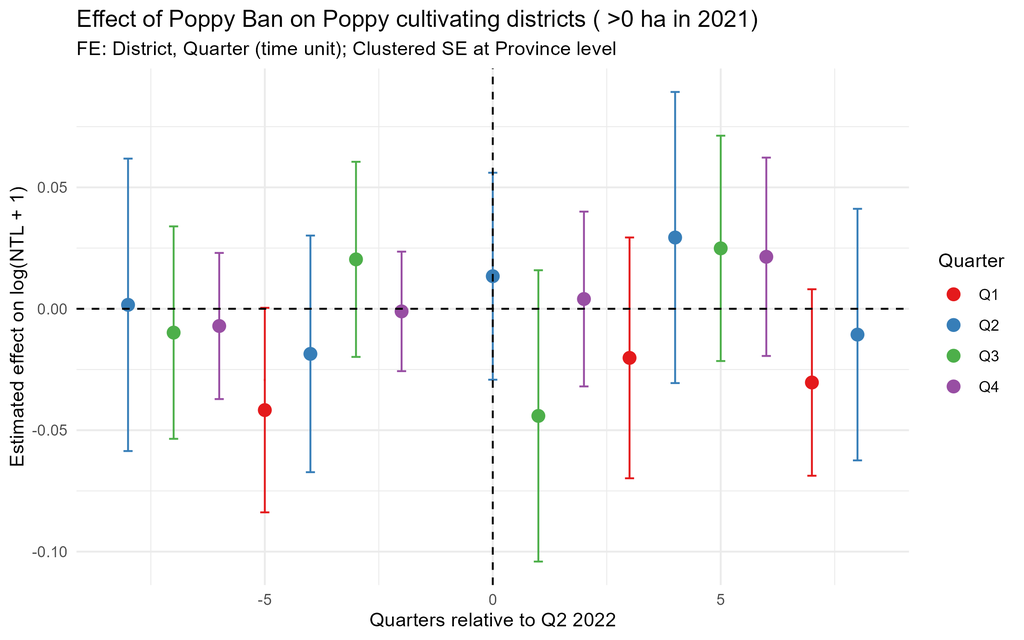

For 2023 “effective” ban

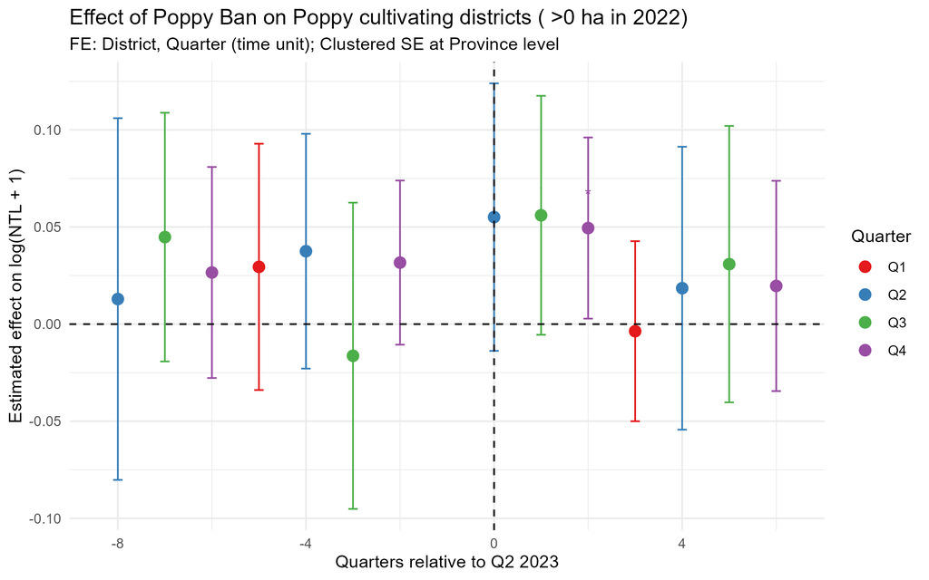

**H2 Taliban Control**

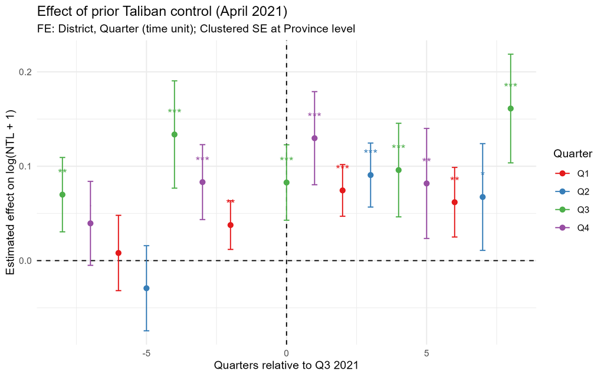